[figure not shown]

# Big Data Analitics Security

### Laboratory 03 "Correlation coeficient"

#### Please insert bellow your firstname, lastnema and ID number and run this cell

Mateusz Wiśniewski 148327

##### (if cell is not active, clik twice on it)

Correlation means the relation between variables. Correlation analysis is used to "catch" whether there is a relation between two variables (properties, characteristics). What does correlation mean? Here it is necessary to understand the relation as a kind of similarity in the "behavior of two characteristics". When one feature, characteristic increases does the other also increase? Or does it decrease? Or does it not change at all?

When calculating the correlation relation between two variables, we get a value whose absolute value (in some correlation coefficients we get both negative and positive values) is called the strength of the correlation, the strength of the relation between two variables. Very often there is a doubt how to interpret the size of such a coefficient, does it mean a strong or weak relationship?

Classification according to J.Guilford:

$|\rho|$=0 - no correlation

$0.0<|\rho|≤0.1$ - weak correlation

$0.1<|\rho|≤0.3$ - weak correlation

$0.3<|\rho|≤0.5$ - average correlation

$0.5<|\rho|≤0.7$ - high correlation

$0.7<|\rho|≤0.9$ - very high correlation

$0.9<|\rho|<1.0$ - almost full correlation

$|\rho|=1$ - full correlation

Peterson's definition is the most commonly used:

According to this definition, the correlation coefficient $\rho(x,y)$ between two verialbles $x$ and $y$ is calculated as follows:

$$\rho(x,y)=\frac{cov(x,y)}{\sigma_x*\sigma_y}$$,

where:

- $cov(x,y)$ is covariance between $x$ and $y$ $$cov(x,y)=E(x∗y)−(E(x)∗E(y))$$
- E(x) expected value of x
- $\sigma_x$ standard deviation for varialble $x$

# Exercise 1 - Correlation calculations

For data presented below, please calculate correlation coeficient accordin tu definition (see description above). Before calculation correlation coeficient, please prepare graph y=f(x).

x = [1, 3, 6, 4, 15, 6, 10, 8, 9, 7, 11, 5, 13, 6, 5]

y = [33, 4, 21, 8, 28, 12, 16, 4, 17, 9, 11, 2, 55, 14, 7]

```python
x = [1, 3, 6, 4, 15, 6, 10, 8, 9, 7, 11, 5, 13, 6, 5]

y = [33, 4, 21, 8, 28, 12, 16, 4, 17, 9, 11, 2, 55, 14, 7]
```

## How to plot data?:

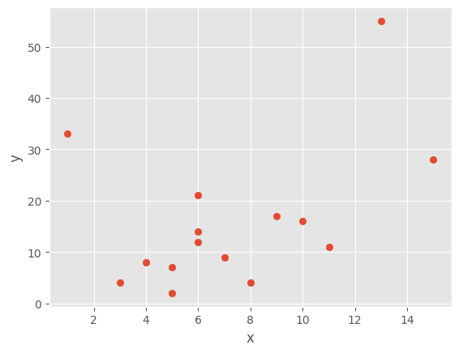

```python
import matplotlib

import matplotlib.pyplot as plt

#data display

matplotlib.style.use('ggplot') # set up the style of graph

#setting axis labels

plt.xlabel('x')

plt.ylabel('y')

#scatter is a function of the Matplotlib library that is used to generate scatter plots in two dimensions.

#the parameters of the function are the values of x, y and colour

plt.scatter(x, y)

plt.show()
```

```python
import numpy as np

def calculate_correlation(x, y):
    x = np.array(x)
    y = np.array(y)
    covariance = np.mean(x * y) - np.mean(x) * np.mean(y)
    correlation = covariance / (np.std(x) * np.std(y))
    return correlation

correlation = calculate_correlation(x, y)
print("Calculated correlation coefficient:", correlation)
```

```
Calculated correlation coefficient: 0.4297838676768133
```

### Correlation coefficient can be calculated with the help numpy library

```python
import numpy as np
correlation = np.corrcoef(x, y)[0,1]
print("The correlation coeffient of the x and y inputs are: \n" ,correlation)
```

```
The correlation coeffient of the x and y inputs are:
 0.42978386767681326
```

#### Calculate correlction coeffient usig numpy library for x nad y data

```python
#code
import numpy as np
correlation = np.corrcoef(x, y)[0,1]
print("The correlation coeffient of the x and y inputs are: \n" ,correlation)
```

```
The correlation coeffient of the x and y inputs are:
 0.42978386767681326
```

# Exercise 2 - Correlation calculations

1. Determine the value of the correlation coefficient for your own data x and y

```python
X = [0, 1, 1.2, 1.5 , 2, 2.7, 3, 3.9, 5.5 , 6]
Y = [0, 0.5, 1, 1.5, 2, 2.5, 3, 3.5, 4, 4.5]

correlation = np.corrcoef(X, Y)[0,1]
print("The correlation coeffient of the X and Y inputs are: \n" ,correlation)
```

```
The correlation coeffient of the X and Y inputs are:
 0.974927471094498
```

2. Find data for which the correlation coefficient will be negative (positive if you got a negative coefficient in the first step)

```python
# Generate data with negative correlation
X = [1, 2, 3, 4, 5, 6, 7, 8, 9, 10]
Y = [10, 9, 8, 7, 6, 5, 4, 3, 2, 1]

correlation = np.corrcoef(X, Y)[0,1]
print("The correlation coefficient of the X_neg and Y_neg inputs is:", correlation)
```

```
The correlation coefficient of the X_neg and Y_neg inputs is: -0.9999999999999999
```

3. Propose and implement apropriate code for generating data with posityve or negative correlation. Plot results.

```python
#code
def generate_positive_correlation():
    X = np.random.rand(10)
    Y = X + np.random.normal(0, 0.1, 10)
    return X, Y

X, Y = generate_positive_correlation()
correlation = np.corrcoef(X, Y)[0,1]
print(correlation)

def generate_negative_correlation():
    X = np.random.rand(10)
    Y = -X + np.random.normal(0, 0.1, 10)
    return X, Y

X, Y = generate_negative_correlation()
correlation = np.corrcoef(X, Y)[0,1]
print(correlation)
```

```
0.8848186082138912
-0.9312043607589162
```

# Exercise 3 - Correlation calculations for real data

Search the Internet for data on:

1. The number of cell phone (mobile device) users in Poland from 1990 to 2023
2. The cost of sending data over mobile networks from 1990 to 2023
3. The amount of data generated by mobile device users from 1990 to 2023

If your search reveals that you cannot find data for a particular year, omit it from your considerations. Display the found data. Save the found data to a file or directly in the code.

For each pair of data, determine the correlation coefficient. Write down the conclusions.

```python
def change_quarter_to_numeric_value(quarter_str):
    # quarter_str is 20XX-QX
    # convert it to 20XX * 10 + X
    year, quarter = quarter_str.split('-Q')
    return int(year) * 10 + int(quarter)
```

```
The correlation coefficient of cell phone users in Poland is: 0.850280404817741
The correlation coefficient of mobile data usage in Singapore is: 0.9501916613254515
The correlation coefficient of telecommunications cost in households is: 0.9283807872066377
```

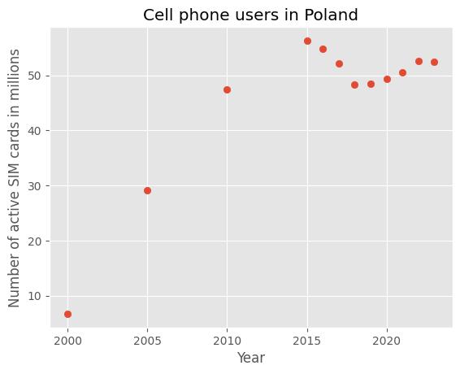

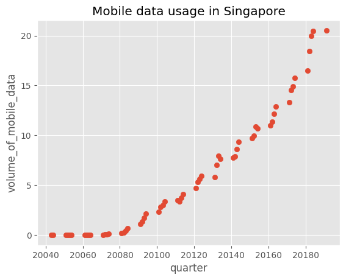

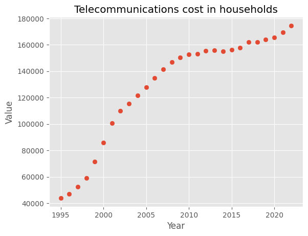

```python
import pandas as pd
import numpy as np

cell_phone_users_df = pd.read_csv('data/cell_phone_users_in_poland.csv', sep=';')
cell_phone_users_X = cell_phone_users_df['Year']
cell_phone_users_Y = cell_phone_users_df['Number of active SIM cards in millions']

mobile_data_usage_df = pd.read_csv('data/mobile_data_usage_singapore.csv', sep=',')
mobile_data_usage_X = mobile_data_usage_df['quarter']
mobile_data_usage_X = mobile_data_usage_X.apply(change_quarter_to_numeric_value)
mobile_data_usage_Y = mobile_data_usage_df['volume_of_mobile_data']

telecommunications_cost_df = pd.read_csv('data/telecommunication_paid_of_households_by_year.csv', sep=',')
telecommunications_cost_X = telecommunications_cost_df['TIME_PERIOD']
telecommunications_cost_Y = telecommunications_cost_df['OBS_VALUE']
# Filter out where unit is CLV10_MEUR
telecommunications_cost_X = telecommunications_cost_X[telecommunications_cost_df['unit'] == 'CLV10_MEUR']
telecommunications_cost_Y = telecommunications_cost_Y[telecommunications_cost_df['unit'] == 'CLV10_MEUR']

correlation = np.corrcoef(cell_phone_users_X, cell_phone_users_Y)[0,1]
print("The correlation coefficient of cell phone users in Poland is:", correlation)

correlation = np.corrcoef(mobile_data_usage_X, mobile_data_usage_Y)[0,1]
print("The correlation coefficient of mobile data usage in Singapore is:", correlation)

correlation = np.corrcoef(telecommunications_cost_X, telecommunications_cost_Y)[0,1]
print("The correlation coefficient of telecommunications cost in households is:", correlation)

import matplotlib.pyplot as plt
plt.scatter(cell_phone_users_X, cell_phone_users_Y)
plt.xlabel('Year')
plt.ylabel('Number of active SIM cards in millions')
plt.title('Cell phone users in Poland')
plt.show()

plt.scatter(mobile_data_usage_X, mobile_data_usage_Y)
plt.xlabel('quarter')
plt.ylabel('volume_of_mobile_data')
plt.title('Mobile data usage in Singapore')
plt.show()

plt.scatter(telecommunications_cost_X, telecommunications_cost_Y)
plt.xlabel('Year')
plt.ylabel('Value')
plt.title('Telecommunications cost in households')
plt.show()
```

# Exercise 4 - Correlation calculations for real data

Propose data for which you will determine the correlation coefficient (e.g. number of airlines, number of passengers).

```
The correlation coefficient of government bond yields in the US is: -0.9258846894204724
```

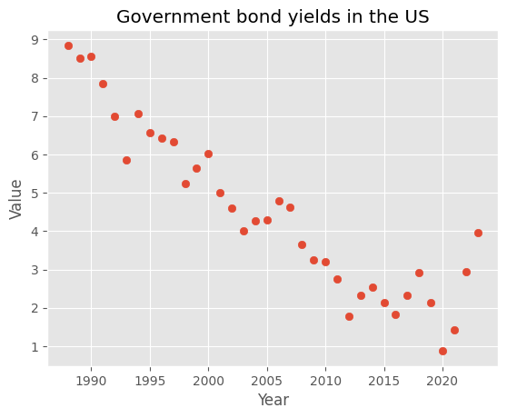

```python
#code
government_bond_yields_df = pd.read_csv('data/government_bond_yields_us.csv', sep=',')
government_bond_yields_X = government_bond_yields_df['TIME_PERIOD']
government_bond_yields_Y = government_bond_yields_df['OBS_VALUE']

correlation = np.corrcoef(government_bond_yields_X, government_bond_yields_Y)[0,1]
print("The correlation coefficient of government bond yields in the US is:", correlation)

plt.scatter(government_bond_yields_X, government_bond_yields_Y)
plt.xlabel('Year')
plt.ylabel('Value')
plt.title('Government bond yields in the US')
plt.show()
```

your conclusions (if not active click twice):

Yields of government bonds have fallen all the way through 1980s-2020 up until the COVID. Then yields started rising again back to 2005 level.

### Answer questions:

1. What risks do you see (e.g., how can you misrepresent) when determining the correlation coefficient?
2. How can these risks be mitigated?

your answers (if not active click twice):

1. Correlation is not causation. Someone might not account other variables that influence the relationship between two displayed values. Correlation also only measures linear relationships and cannot display non-linear ones effectively. Additionally sample size needs to be big enough for correlation to be meaningful.
- Visualize plots to better understand data
- Check for outliers
- Ensure big sample data size
- Use non-linear methods